# Football Analysis Report

```r
# Libraries used
library(dplyr)
library(tidyverse)
library(tidyr)
```

## Part A: Prepare the data for analysis

### 1, Read in data

Read from different files

```r
player_salary <- read.csv('player_salary.csv',
                    header = TRUE,
                    sep = ',')
coach_salary <- read.csv('coach_salary.csv',
                    header = TRUE,
                    sep = ',')
coach_record <- read.csv('coach_record.csv',
                    header = TRUE,
                    sep = ',')
```

### 2, Cleaning data

The following part describes how we clean the data. We hide the code to avoid unreasonable length of this report.

#### 2.1 General information of the datasets

We first take a brief look at the datasets of their descriptive statistics.

```r
summary(player_salary)
```

```
##    position            player              team                age
##  Length:5523        Length:5523        Length:5523        Min.   :   0.0
##  Class :character   Class :character   Class :character   1st Qu.:  24.0
##  Mode  :character   Mode  :character   Mode  :character   Median :  25.0
##                                                           Mean   : 187.9
##                                                           3rd Qu.:  28.0
##                                                           Max.   :2020.0
##   total_value           avg_year        total_guaranteed    fully_guaranteed
##  Min.   :   105000   Min.   :       0   Min.   :        0   Min.   :       0
##  1st Qu.:  1350000   1st Qu.:  585333   1st Qu.:        0   1st Qu.:       0
##  Median :  2075000   Median :  690000   Median :    90000   Median :   87056
##  Mean   :  7786235   Mean   : 2250830   Mean   :  3803250   Mean   : 3095552
##  3rd Qu.:  4673694   3rd Qu.: 2000000   3rd Qu.:  1600000   3rd Qu.: 1500000
##  Max.   :150000000   Max.   :35000000   Max.   :107000000   Max.   :94500000
##  free_agency
##  Length:5523
##  Class :character
##  Mode  :character
##
##
##
```

```r
summary(coach_salary)
```

```
##      name               team             Division         Annual.Salary
##  Length:32          Length:32          Length:32          Length:32
##  Class :character   Class :character   Class :character   Class :character
##  Mode  :character   Mode  :character   Mode  :character   Mode  :character
##   Net.worth           position
##  Length:32          Length:32
##  Class :character   Class :character
##  Mode  :character   Mode  :character
```

```r
summary(coach_record)
```

```
##       X                 X.1                X.2            Overall.Record
##  Length:33          Length:33          Length:33          Length:33
##  Class :character   Class :character   Class :character   Class :character
##  Mode  :character   Mode  :character   Mode  :character   Mode  :character
##      X.3                X.4                X.5                X.6
##  Length:33          Length:33          Length:33          Length:33
##  Class :character   Class :character   Class :character   Class :character
##  Mode  :character   Mode  :character   Mode  :character   Mode  :character
##    Service              X.7            Championships          X.8
##  Length:33          Length:33          Length:33          Length:33
##  Class :character   Class :character   Class :character   Class :character
##  Mode  :character   Mode  :character   Mode  :character   Mode  :character
##      X.9                X.10
##  Length:33          Length:33
##  Class :character   Class :character
##  Mode  :character   Mode  :character
```

Check if there are Na values.

```r
# Check if there are NA values
# for (i in sheet.index){
#   print(data.list[[i]] %>% is.na() %>% sum())
# }
print(player_salary%>% is.na() %>% sum())
```

```
## [1] 0
```

```r
print(coach_salary%>% is.na() %>% sum())
```

```
## [1] 0
```

```r
print(coach_record%>% is.na() %>% sum())
```

```
## [1] 0
```

##### 2.1.1. missing values

Delete some unreasonable and missing values.

```r
# replicate the original model for cleaning
player_salary_ <- player_salary
coach_salary_ <- coach_salary
coach_record_ <- coach_record

# Finding the missing value, and filled in with internet searching result
coach_salary_ <- coach_salary
coach_salary_[c(which(is.na(coach_salary)==TRUE, arr.ind = TRUE)[,1]),5] <- '2.5 million'
```

##### 2.1.2 Fix column names

change all the column names into underline format.

```r
colnames(coach_record_) <- c(coach_record_[1,])
coach_record_ <- coach_record_[-1,]
rownames(coach_record_) <- c(1:nrow(coach_record_))

colnames(coach_salary_) <- c(colnames(coach_salary_)[1:3], 'Annual_salary', 'Net_worth', colnames(coach_salary_)[6])
```

##### 2.1.3 change the variable type

2.1.3.1. **coach_salary**  
* *Annual_salary* * This is changed into numerical

```r
# for (i in 1:nrow(coach_salary_)){
#   coach_salary_[i, 'Annual_salary'] <- gsub('\\$', '', coach_salary_[i, 'Annual_salary'])
#   coach_salary_[i, 'Annual_salary'] <- gsub(' ' , '', coach_salary_[i, 'Annual_salary'])
# }
```

```r
no_mill <- c(which(!agrepl('million', coach_salary_$Annual_salary, ignore.case = T)))

# paste 'million' to uniform these cells
for (i in no_mill)
  coach_salary_[i,'Annual_salary'] <- paste(coach_salary_[i,'Annual_salary'], 'million', collapse = ' ')

# coach_salary_
```

```r
coach_salary_ <- separate(coach_salary_, Annual_salary, c('income', NA), ' ')

# coach_salary_
```

```r
# Keep numeric parts and change variable type to numeric
for (i in 1:nrow(coach_salary_))
  coach_salary_[i,'income'] <-
substr(coach_salary_[i, 'income'], 2, nchar(coach_salary_[i,'income']))

# coach_salary_
```

```r
coach_salary_[23,'income'] <- '0.1'
coach_salary_[24,'income'] <- '4'
coach_salary_[26,'income'] <- '3.025'
coach_salary_[30,'income'] <- '3.5'
coach_salary_[31,'income'] <- '0.5'
# coach_salary_
```

```r
coach_salary_ <- mutate(coach_salary_, 'Annual_salary'=as.numeric(coach_salary_$income)*1000000)
# coach_salary_
```

- *Net_salary* * This is also changed to numeric variable, there were missing piece warning, which is waht we want to get rid of in the str type, so just ignore it.

```r
# Remove dollar sign and trim
for (i in 1:nrow(coach_salary_)){
  coach_salary_[i, 'Net_worth'] <- gsub('\\$', '', coach_salary_[i, 'Net_worth'])
  coach_salary_[i, 'Net_worth'] <- gsub(' ' , '', coach_salary_[i, 'Net_worth'])
}

coach_salary_ <- separate(coach_salary_, Net_worth, c('net', NA), 'million')

coach_salary_$net <- as.double(coach_salary_$net)*1000000

coach_salary_ <- rename(coach_salary_, 'Net_worth'='net')
```

2.1.3.2 **coach_record** Change this to double type

```r
for (i in 4:ncol(coach_record_))
  coach_record_[,i] <- as.double(coach_record_[,i])
```

##### 2.1.4. Separate variables

- **player_salary** Seperate agency and end time. There is warning saying missing value which is taken care of in the next part.

```r
player_salary_ <- player_salary %>% separate(free_agency, c('agency_time', 'type'),' ')
```

```
## Warning: Expected 2 pieces. Missing pieces filled with `NA` in 5 rows [316, 537,
## 1097, 2387, 2831].
```

```r
# There's warning of NA's in the dataset

# Extract rows with NA values
# player_salary_[c(which(is.na(player_salary_)==TRUE, arr.ind = TRUE)[,1]),]

# These are not top players
# the number of missing data is not very large, so we just drop them
player_salary_ <- player_salary_[-c(which(is.na(player_salary_)==TRUE, arr.ind = TRUE)[,1]) ,]
rownames(player_salary_) <- c(1:nrow(player_salary_))

player_salary_$agency_time <- as.numeric(player_salary_$agency_time)
```

#### 2.1.5, Fix abnormal data

Replace age larger than 50 or smaller than 15 with mean age of the rest age data.

There are three 0 values in *avg_year*, so we just delete them.

```r
player_salary_ <- player_salary_[player_salary_$avg_year != 0,]
```

#### 2.1.6, Repeated variable

There were few positions in **player_salary** are the same, merge them as needed: (1) **3-4-defensive-end** and **4-3-denfensive-end**  
(2) **3-4-denfensive-tackle** and **4-3-defensive-tackle** (both belong to **defensive-line**)  
(3) **linebacker**, **traditional-linebacker**, and **insider-linebacker**  
(4) **3-4-outside-linebacker** and **4-3-outside-linebacker** There are some positions belongs to the other, they are:  
**cornerback** and **safty** belong to **defensive-back**  
**center** belong to **offensive-line**  
**3-4-denfensive-tackle** and **4-3-defensive-tackle** (both belong to **defensive-line**)

```r
player_salary_[player_salary_$position=='3-4-defensive-end','position'] <- '4-3-defensive-end'

player_salary_[player_salary_$position=="3-4-defensive-tackle",'position'] <- "4-3-defensive-tackle"

player_salary_[player_salary_$position=='traditional-linebacker','position'] <- "linebacker"
player_salary_[player_salary_$position=="inside-linebacker",'position'] <- "linebacker"

player_salary_[player_salary_$position=='3-4-outside-linebacker','position'] <- '4-3-outside-linebacker'
```

Here is the data we eventually have:

```r
player_salary <- player_salary_
coach_record <- coach_record_
coach_salary <- coach_salary_
head(player_salary)
```

```
##       position               player     team age total_value avg_year
## 1 right-tackle          Trent Brown  Raiders  26    66000000 16500000
## 2 right-tackle Ja\xa1\xafWuan James  Broncos  27    51000000 12750000
## 3 right-tackle         Lane Johnson   Eagles  29    56250000 11250000
## 4 right-tackle         Ricky Wagner    Lions  30    47500000  9500000
## 5 right-tackle       Rob Havenstein     Rams  26    32500000  8125000
## 6 right-tackle         Morgan Moses Redskins  28    40000000  8000000
##   total_guaranteed fully_guaranteed agency_time type
## 1         36250000         36250000        2023  UFA
## 2         32000000         27000000        2023  UFA
## 3         35500000         20862242        2022 Void
## 4         29500000         17500000        2022  UFA
## 5         16226365          9976365        2023  UFA
## 6         20000000         14047000        2023  UFA
```

```r
head(coach_record)
```

```
##             Name Team          Seasons Gms   W   L T   Pct Yrs Post DIV CON LG
## 1 Bill Belichick   NE    1991-95,00-21 464 313 151 0 0.675  27   18  17   9  6
## 2      Andy Reid   KC          1999-21 389 240 148 1 0.618  23   16  11   3  1
## 3   Pete Carroll  SEA 1994,97-99,10-21 266 158 107 1 0.596  16   11   6   2  1
## 4    Mike Tomlin  PIT          2007-21 245 155  89 1 0.635  15    9   7   2  1
## 5    Sean Payton   NO    2006-11,13-21 246 155  91 0 0.630  15    9   7   1  1
## 6  Mike McCarthy  DAL    2006-18,20-21 243 145  96 2 0.601  15    9   6   1  1
##   SB
## 1  6
## 2  1
## 3  1
## 4  1
## 5  1
## 6  1
```

```r
head(coach_salary)
```

```
##             name                 team  Division income Net_worth   position
## 1 Bill Belichick New England Patriots  AFC-East     12   3.5e+07 head coach
## 2   Pete Carroll     Seattle Seahawks  NFC-West     11   2.2e+07 head coach
## 3     Jon Gruden    Las Vegas Raiders   AFC-est     10   3.0e+07 head coach
## 4    Sean Payton   New Orleans Saints NFC-South    9.8   2.2e+07 head coach
## 5  John Harbaugh     Baltimore Ravens AFC-North      9   1.6e+07 head coach
## 6     Matt Rhule    Carolina Panthers NFC-South    8.5   5.0e+06 head coach
##   Annual_salary
## 1       1.2e+07
## 2       1.1e+07
## 3       1.0e+07
## 4       9.8e+06
## 5       9.0e+06
## 6       8.5e+06
```

## Part B: Data analysis

### 1 Analysis of Total value

We want to know how the *total_value* varies by age, position, and team. We’ll also do computations to showsome correlation.

#### 1.1 average total value of each position

```r
posSa <- player_salary_ %>% group_by(player_salary_$position) %>%
  summarise(avg <- mean(total_value))
posSa <- as.data.frame(posSa)
posSa[order(posSa$`avg <- mean(total_value)`,decreasing=T),]
```

```
##    player_salary_$position avg <- mean(total_value)
## 18             quarterback                 19969326
## 8              edge-rusher                 11647101
## 13             left-tackle                 11013873
## 1        4-3-defensive-end                 10994316
## 7           defensive-line                  9107187
## 16          offensive-line                  9006569
## 20            right-tackle                  8307251
## 4                   center                  8110696
## 19             right-guard                  8096270
## 3   4-3-outside-linebacker                  8013763
## 12              left-guard                  7955430
## 10 interior-defensive-line                  7685334
## 5               cornerback                  7437160
## 24           wide-receiver                  6806289
## 6           defensive-back                  6742654
## 2     4-3-defensive-tackle                  6382798
## 14              linebacker                  6307806
## 22                  safety                  5828116
## 11                  kicker                  5640782
## 23               tight-end                  4951559
## 17                  punter                  4773773
## 21            running-back                  4741030
## 9                 fullback                  3532030
## 15            long-snapper                  2448724
```

This slide shows that quarterback position has the highest average salary. Positions like quarterback, edge-rusher, tackle, and 4-3-defensive-end positions make over 10 millions.

#### 1.2 number of players of each position

```r
frequency <- player_salary_ %>% group_by(player_salary_$position)%>%
  summarise(n = n())
frequency <- as.data.frame(frequency)
frequency[order(frequency$n,decreasing = T),]
```

```
##    player_salary_$position   n
## 14              linebacker 837
## 6           defensive-back 548
## 16          offensive-line 489
## 7           defensive-line 426
## 24           wide-receiver 383
## 5               cornerback 314
## 10 interior-defensive-line 271
## 1        4-3-defensive-end 248
## 22                  safety 233
## 8              edge-rusher 218
## 21            running-back 197
## 3   4-3-outside-linebacker 196
## 23               tight-end 195
## 2     4-3-defensive-tackle 181
## 18             quarterback 119
## 13             left-tackle 111
## 19             right-guard 108
## 20            right-tackle 100
## 12              left-guard  97
## 4                   center  90
## 17                  punter  46
## 11                  kicker  44
## 15            long-snapper  42
## 9                 fullback  22
```

#### 1.3 average salary of each team

```r
teamSa <- player_salary_  %>% group_by(player_salary_ $team) %>%
  summarise(avg <- mean(total_value))
teamSa <- as.data.frame(teamSa)
teamSa[order(teamSa$`avg <- mean(total_value)`,decreasing=T),]
```

```
##    player_salary_$team avg <- mean(total_value)
## 32             Vikings                 11155185
## 2                Bears                  9636364
## 1                49ers                  9494696
## 6               Browns                  9013063
## 26            Redskins                  8943277
## 20             Packers                  8803744
## 14              Eagles                  8685926
## 17             Jaguars                  8538031
## 31              Titans                  8362323
## 19               Lions                  8296689
## 12             Cowboys                  8199380
## 24                Rams                  8137855
## 18                Jets                  8057762
## 7           Buccaneers                  8001185
```

[output cut: 18 more lines]

This shows that the team Vikings earns the most in terms of the total value which is the amount of money on the contract.

#### 1.4 average total value of each age group

```r
unique(player_salary$age)
```

```
##  [1] 26.00000 27.00000 29.00000 30.00000 28.00000 31.00000 23.00000 34.00000
##  [9] 25.00000 24.00000 26.07252 22.00000 37.00000 33.00000 32.00000 35.00000
## [17] 38.00000 36.00000 21.00000 41.00000 39.00000 47.00000 40.00000 42.00000
```

```r
ageSa <- player_salary_  %>% group_by(player_salary_ $age) %>%
  summarise(avg <- mean(total_value))
ageSa <- as.data.frame(ageSa)
ageSa[order(ageSa$`avg <- mean(total_value)`,decreasing=T),]
```

```
##    player_salary_$age avg <- mean(total_value)
## 21           40.00000                 50000000
## 23           42.00000                 41000000
## 19           38.00000                 34395714
## 11           30.00000                 26115448
## 12           31.00000                 24368405
## 15           34.00000                 21186348
## 10           29.00000                 19782340
## 17           36.00000                 16293077
## 9            28.00000                 16011379
## 13           32.00000                 15152429
## 16           35.00000                 14556389
## 18           37.00000                 14531400
## 14           33.00000                 13254022
## 8            27.00000                  9408572
## 6            26.00000                  6546534
## 2            22.00000                  4564270
## 1            21.00000                  4433961
## 5            25.00000                  4293364
## 24           47.00000                  3875000
## 3            23.00000                  3364737
## 4            24.00000                  3269501
## 7            26.07252                  3145965
## 20           39.00000                  2350000
## 22           41.00000                  1120000
```

#### 1.5 age and total value correlation

```r
cor(player_salary_ $total_value,player_salary_ $age)
```

```
## [1] 0.3345937
```

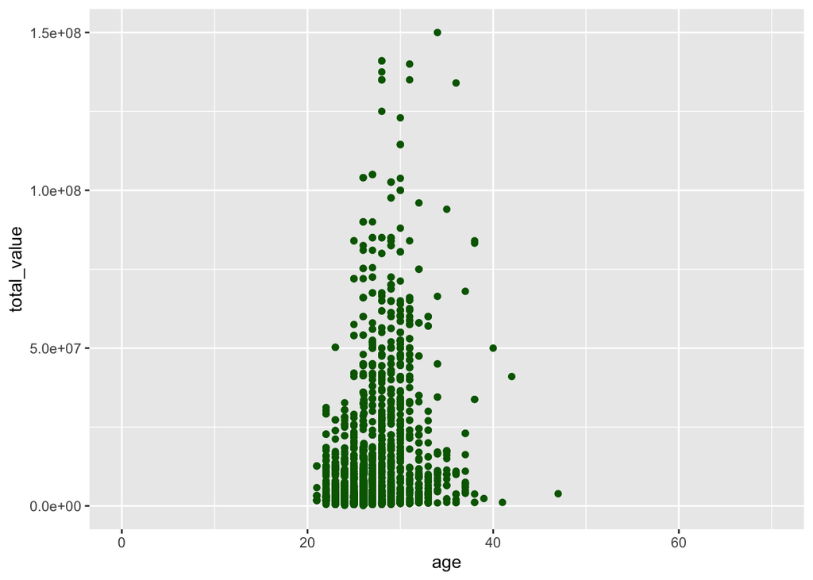

```r
corAge <- ggplot(data=player_salary_ ,aes(x=age,y=total_value))+xlim(0, 70)+geom_point(color ="darkgreen")
corAge
```

#### 1.6 is total value positively correlated with fully guaranteed?

```r
cor(player_salary_ $total_value,player_salary_ $fully_guaranteed)
```

```
## [1] 0.9111312
```

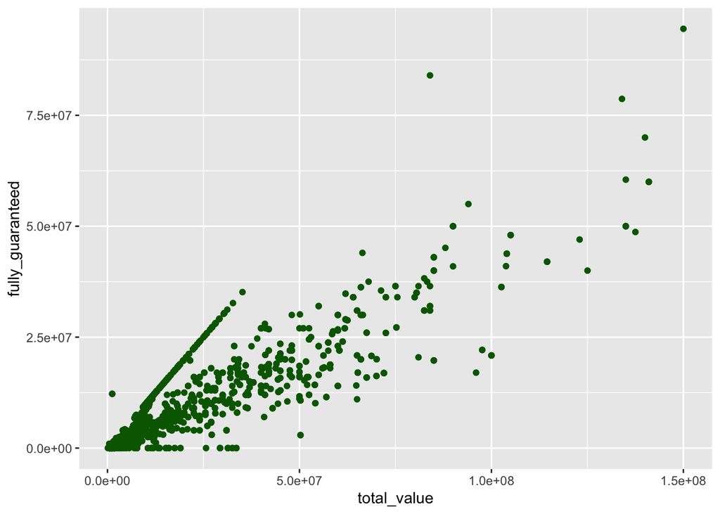

```r
corValue <- ggplot(data=player_salary_ ,aes(x=total_value,y=fully_guaranteed))+
  geom_point(color ="darkgreen")
corValue
```

It shows that total_value and fully_guaranteed are highly correlated.

### 2 What are the variables related to high salary of players?

We discuss the how **total_value** varies in the part 1, now we are interested in how the player are paid year by year, which is **avg_year** so they have such huge accumulative **tptal_value**. We propose the following:

#### 2.1 position

Position is the most intuitively reason we would associate with income – there are positions more important in a game, they are supposed to make more money.

##### 2.1.1 Average highest

I take the average over the annual salary after grouping them by position.

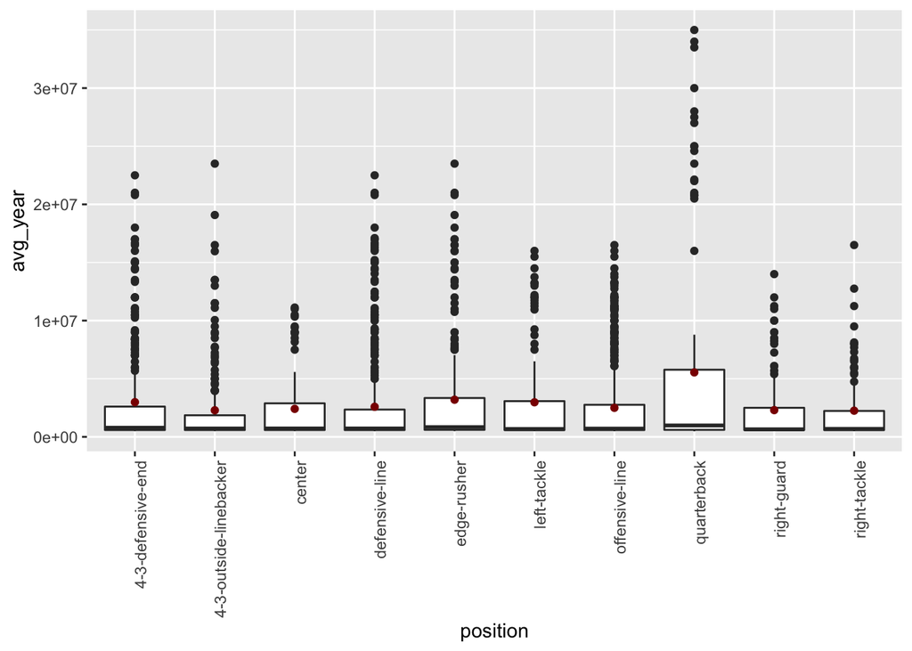

```r
# unique(player_salary$position)#24 positions in the data

# Select columns of position, avg_year, player to find positions with the highest salary

position_sub<- player_salary[c('position','avg_year')]%>%
  group_by(position)

p <- position_sub %>%
      summarize_each(funs(mean)) %>%
      arrange(desc(avg_year)) %>%
      head(10) %>%
      select(position) %>%
      inner_join(position_sub, by='position') %>%
      group_by(position) %>%
      ggplot(aes(x=position, y=avg_year))+
      geom_boxplot(aes(fill=avg_year)) +
      theme(axis.text.x = element_text(angle=90, hjust = 1))
p + stat_summary(fun=mean, color='darkred', geom='point') #red dot identifies the mean value
```

If we look at the number of positions by `unique()`, we see there are 24 positions, but we are concentrating on the highest ones, so I keep the top 10 average salary positions to display in the plot. Red dot in the plot identifies the average value.  
Though the boxes are scaled by large value outliers, we cannot remove those outliers, because they represent the extraordinarily high paid players in each position, we’ll take care of them later, Now I will zoom in to show the tendency, of these average values.

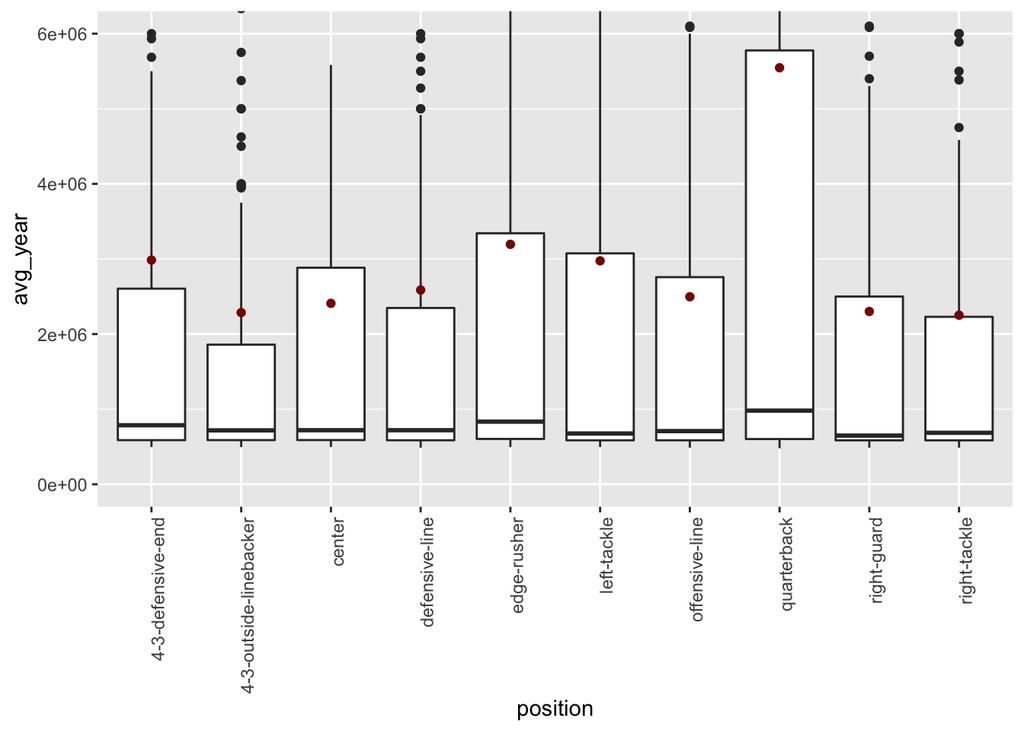

```r
p + stat_summary(fun=mean, color='darkred', geom='point') +
    coord_trans(x = "identity", y = "identity", xlim = NULL, ylim = c(0,6e+6))
```

If we look at this zoomed in plot, we find the avarage annual salary of **quarterback** is getting close to 6 million, which could be twice of the number of 4-3 outside linebacker, but there are still 14 positions not showed here, so **quarterback** is indeed a highly-paid position.

If we take a closer look at the boxplot, we find all the medians are close to the bottom of the box and much lower than the red dots, which means high-paid players extensively raise the mean value, so we would like to look at those extraordinarily high paid players, i.e. the outliers mentioned before.

##### 2.1.2 Top highest in each position

Here we extract top 10 highest paid players in top 10 high-paid positions, and plot the average annual salary versus position,

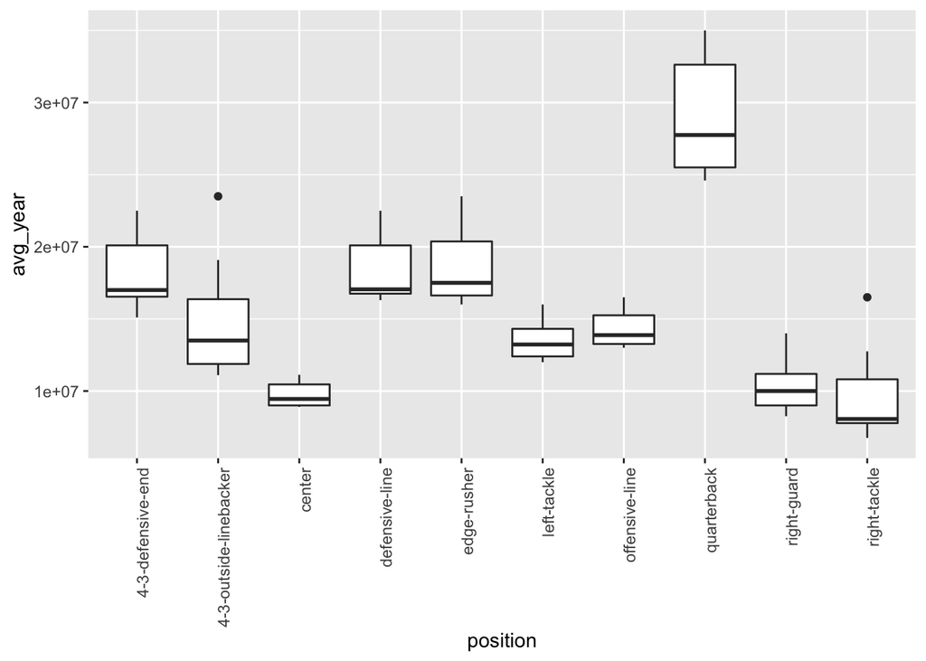

```r
top_10_each_position <- position_sub %>%
                          summarize_each(funs(mean)) %>%
                          arrange(desc(avg_year)) %>%
                          head(10) %>%
                          select(position) %>%
                          inner_join(position_sub, by='position') %>%
                          group_by(position) %>%
                          slice_max(order_by = avg_year, n = 10)

ggplot(top_10_each_position, aes(x=position, y=avg_year))+
      geom_boxplot() +
      theme(axis.text.x = element_text(angle=90, hjust = 1))
```

This plots shows that even in the most-paid subset, **quarterback** has the obvious highest yearly pay. If we look at the overall trend of each position, they follow a similar trend we had in the previous box plot.

#### 2.2 age

Another factor matters to salary could be age. It is conceivable that a player at younger age tend to be more energetic and active while older players are more experience at team-work and techniques, so there could be an optimum age preferred by clubs and willing to pay more.

##### 2.2.1 Top player age distribution

To look at if age affect salary, we will first look at the most paid players in each position to see their age distribution.

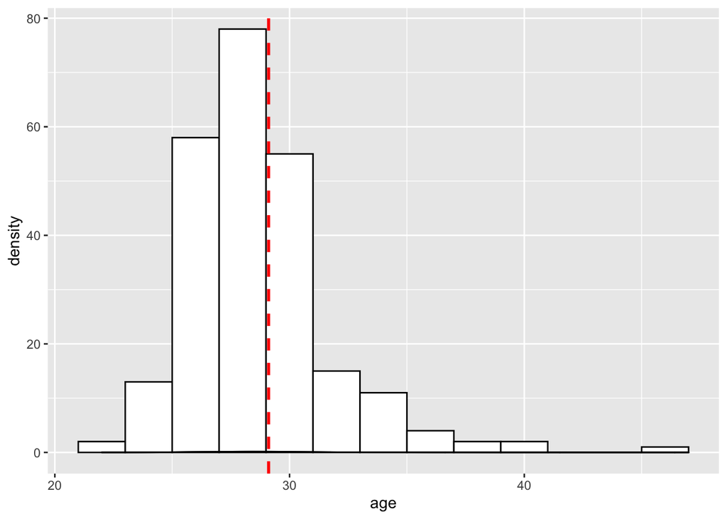

```r
player_salary %>% group_by(position) %>% slice_max(order_by = avg_year, n = 10) %>%
  ggplot(aes(x=age)) +
  geom_histogram(binwidth = 2,
                 color='black',
                 fill='white')+
   geom_density() +
   geom_density(alpha=.2, fill='#FF6666')+
   geom_vline(aes(xintercept=mean(age, na.rm=T)),
               color="red", linetype="dashed", size=1) #red dash is the mean
```

This plot has bin width of 2, and the red dashed line marks the mean of the distribution. We found most top-paid players have age between 25 and 31, and the mean is 29, very few of them are over 40, so this distribution is slightly right-skewed.

##### 2.2.1 All players age distribution

We also interested in age distribution of all players, so we plot this:

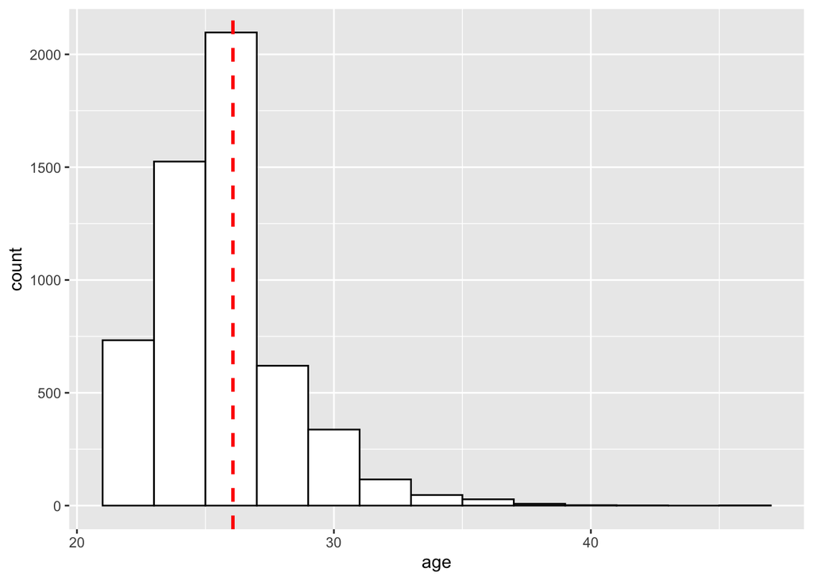

```r
player_salary %>%
  ggplot(aes(x=age)) +
  geom_histogram(binwidth = 2,
                 color='black',
                 fill='white')+
   # geom_density(alpha=.2, fill="#FF6666")+
   geom_vline(aes(xintercept=mean(age, na.rm=T)),
               color="red", linetype="dashed", size=1)
```

#### 2.3 team

Just like some companies are willing to pay more to their employees, annual salary can vary by teams.

##### 2.3.1 Average salary versus team

We take average of each team and plot the following:

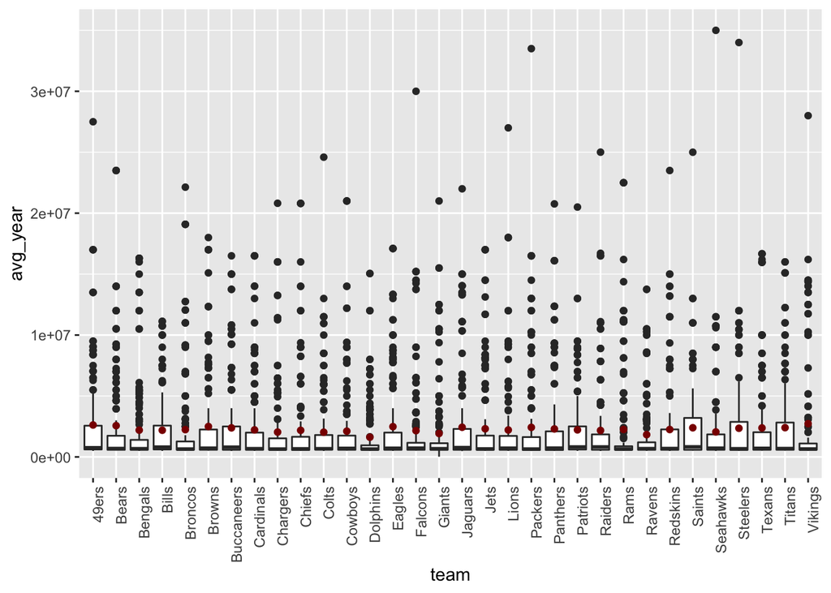

```r
# Average
# head(player_salary)
# player_salary %>% group_by(team) %>% select(c('team','avg_year')) %>% summarize_each(funs(mean)) %>%
#   ggplot(aes(x=team))+geom_boxplot() + theme(axis.text.x = element_text(angle=90, hjust = 1))

p <-player_salary[,c('team','avg_year')] %>% group_by(team) %>%
      summarize_each(funs(mean)) %>%
      arrange(desc(avg_year)) %>%
head(32) %>%
select(team) %>%
inner_join(player_salary[,c('team','avg_year')], by='team') %>%
group_by(team)%>%
ggplot(aes(x=team, y=avg_year))+
geom_boxplot(aes(fill=avg_year))+
theme(axis.text.x = element_text(angle=90, hjust = 1))
p + stat_summary(fun=mean, color='darkred', geom='point') #red dot identifies the mean value
```

As what happened in position, there are outliers in each team. There seems a fluctuation, zoom in to identify the tendency.

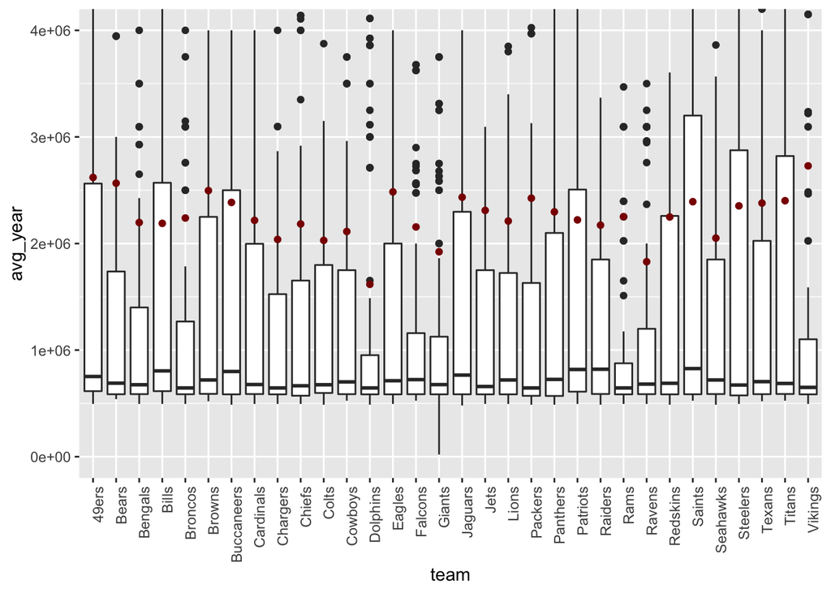

```r
p + stat_summary(fun=mean, color='darkred', geom='point') +
    coord_trans(x = "identity", y = "identity", xlim = NULL, ylim = c(0,4e+6))
```

Unlike the position, there is not an outstanding best-paid team, rather, there are few less-paid teams, so let’s look at the bar plot.

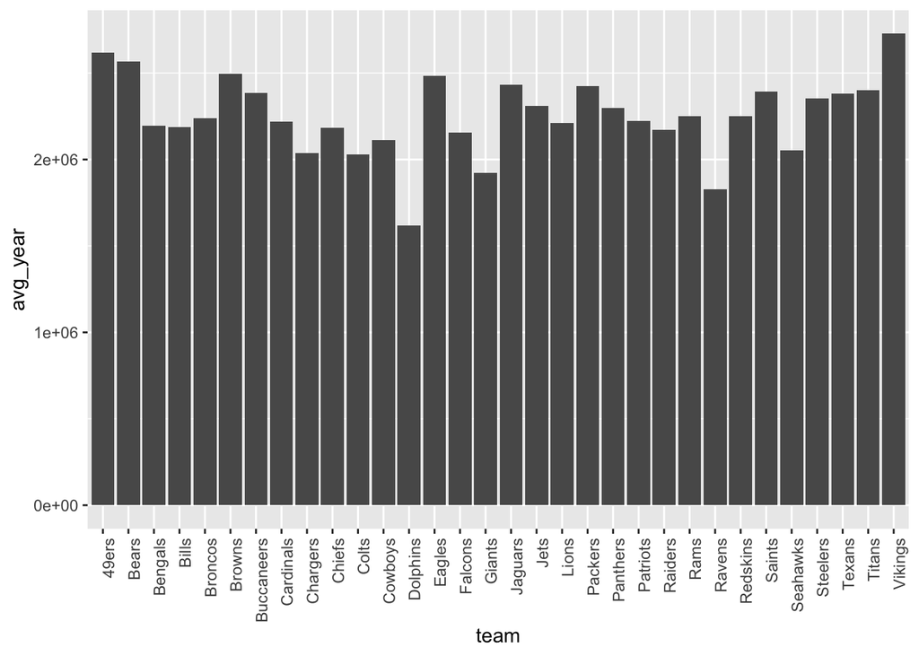

```r
less_team <- player_salary[,c('team','avg_year')] %>%
      group_by(team) %>%
      summarize_each(funs(mean)) %>%
      arrange(avg_year) %>%
      head(16) %>%
      select(team) %>%
      inner_join(player_salary[,c('team','avg_year')], by='team') %>%
      group_by(team) %>%
      summarize_each(funs(mean)) %>%
      mutate(Rate='Lo')
hi_team <- player_salary[,c('team','avg_year')] %>%
      group_by(team) %>%
      summarize_each(funs(mean)) %>%
      arrange(desc(avg_year)) %>%
      head(16) %>%
      select(team) %>%
      inner_join(player_salary[,c('team','avg_year')], by='team') %>%
      group_by(team) %>%
      arrange(desc(avg_year)) %>%
      summarize_each(funs(mean)) %>%
      mutate(Rate='Hi')
hi_low_team <- rbind(hi_team, less_team)

ggplot(hi_low_team, aes(x=team, y=avg_year))+
  theme(axis.text.x = element_text(angle=90, hjust = 1))+
  geom_bar(stat = 'identity')
```

```r
  # facet_grid(. ~ Rate)
```

In this bar plot, we can see the average annual of each team fluctuates between 2 million and 2.5 million without outstanding high value. But there are two teams: *Dolphins*, *Ravens* are obviously have lower values than the other teams. We know that *headquarter* is the position to have higher salary, so we want to know if these teams are paying lower salary depends on positions.

Here we plot the average annual salary distributions by positions. To compare the how are the position investing strategy of *Dolphins* and *Ravens* are different from the overall trend, we put the plots together.

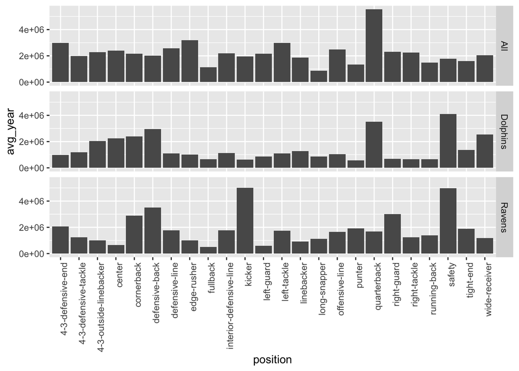

```r
all_team <- player_salary[,c('avg_year', 'position')]  %>%
                group_by(position) %>%
                summarise_each(funs(mean))%>%
                mutate(Distr = 'All')

Dolphins_team <-
            player_salary[player_salary$team=='Dolphins' ,c('avg_year', 'position')]%>%
                group_by(position) %>%
                summarise_each(funs(mean))%>%
                mutate(Distr ='Dolphins')

Ravens_team <- player_salary[player_salary$team=='Ravens' ,c('avg_year', 'position')] %>%
                group_by(position) %>%
                summarise_each(funs(mean))%>%
                mutate(Distr ='Ravens')

position_team <- rbind(all_team, Dolphins_team, Ravens_team)
ggplot(position_team, aes(x=position, y=avg_year))+
  theme(axis.text.x = element_text(angle=90, hjust = 1))+
  geom_bar(stat = 'identity')+
  facet_grid(Distr ~ .)
```

These three plots are different in their own way, but one noteworthy position is *Safty*. Both *Dolphins* and *Ravens* are willing to pay a lot to this position. But if we look at the top most plot, that’s not the case. It’s probably that these two teams have good defense performance in the games.

# 4. How many players will be free agency by 2022?

The graph below shows the number of free agency players per year. As explained earlier, free agency means that these players will be free to negotiate with other teams by the year that their contract ends. As we can see in the graph, there will be almost 5,000 free agency players by 2022, taking in count from 2017 to 2022. Also, the figure shows a trend of decreasing the number of free agency players from 2020 to 2025. This trend might be due to many players ending their contract to start a new one.

```r
# Cheking how many player will be free agency by 2022
df_free <- player_salary %>% dplyr::filter(agency_time >= 2022)
nrow(df_free)
```

```
## [1] 2208
```

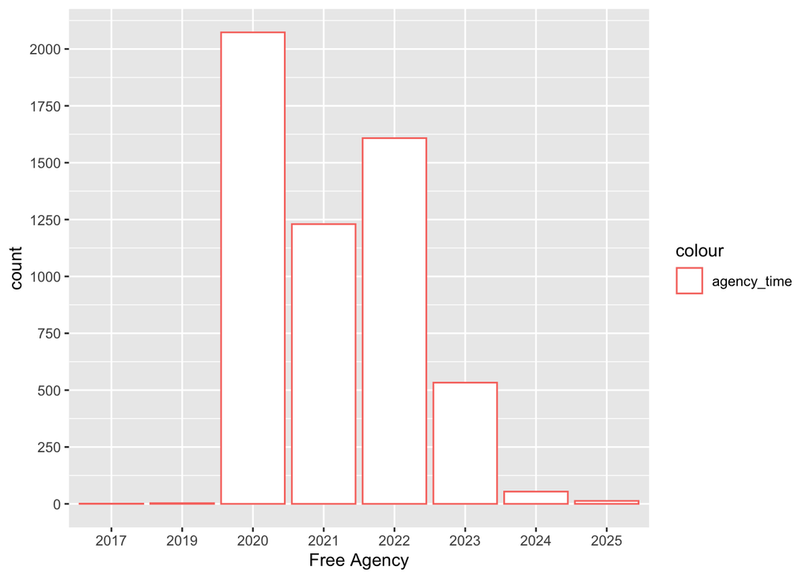

```r
# Plotting
df_agency <- player_salary
df_agency$agency_time <- as.factor(df_agency$agency_time)

ggplot(df_agency, aes(x= agency_time, color="agency_time")) +
    geom_bar(stat = "count", fill="white") +
    labs(x = "Free Agency") +
  #ylim(0, 2500) +
  scale_y_continuous(breaks = seq(0, 2500, by = 250))
```

```r
  ggtitle("Number of players by free agency years")
```

```
## $title
## [1] "Number of players by free agency years"
##
## attr(,"class")
## [1] "labels"
```

# 5. What are the 20 MVP players based on their earns?

The list below presents the 20 MVP, which stand for the 20 Most Valuable Players from the NFL league. For that calculation, we considered values from the dataset such as average per year (avg_year), total_guaranteed, and fully_guaranteed. As we can see, most of the player’s positions on this list are a quarterback. The top three were Matt Ryan (Falcons), Russel Wilson (Seahawks), and Aaron Rodgers (Packers).

```r
# Creating column with MVP value
df_MVP <- player_salary %>%
  rowwise() %>%
  mutate(MVP_value = sum(avg_year, total_guaranteed, fully_guaranteed))

# Removing duplicated players'name
df_MVP <- df_MVP %>% distinct(player, .keep_all= TRUE)
# Organizing it by sorting as ascending values
df_MVP <- df_MVP[order(df_MVP$MVP_value),]
# Extracting the 20 highest MVP_values
df_20 <- tail(df_MVP, n= 20)
# The 20 most valuable players (MVP) are:
df_20$player
```

```
##  [1] "Cam Newton"         "Eli Manning"        "Philip Rivers"
##  [4] "Odell Beckham, Jr." "Trey Flowers"       "Frank Clark"
##  [7] "Joe Flacco"         "Von Miller"         "Demarcus Lawrence"
## [10] "Derek Carr"         "Alex Smith"         "Jimmy Garoppolo"
## [13] "Andrew Luck"        "Aaron Donald"       "Khalil Mack"
## [16] "Matt Stafford"      "Kirk Cousins"       "Aaron Rodgers"
## [19] "Russell Wilson"     "Matt Ryan"
```

```r
# Which position has more MVP's?
df_20$position <- as.factor(df_20$position) # making position as factor

# Removing duplicated players'name
df_MVP <- df_MVP %>% distinct(player, .keep_all= TRUE)

# Organizing it by sorting as ascending values
df_MVP <- df_MVP[order(df_MVP$MVP_value),]

# Extracting the 20 highest MVP_values
df_20 <- tail(df_MVP, n= 20)

# The 20 most valuable players (MVP) are:
df_20$player
```

```
##  [1] "Cam Newton"         "Eli Manning"        "Philip Rivers"
##  [4] "Odell Beckham, Jr." "Trey Flowers"       "Frank Clark"
##  [7] "Joe Flacco"         "Von Miller"         "Demarcus Lawrence"
## [10] "Derek Carr"         "Alex Smith"         "Jimmy Garoppolo"
## [13] "Andrew Luck"        "Aaron Donald"       "Khalil Mack"
## [16] "Matt Stafford"      "Kirk Cousins"       "Aaron Rodgers"
## [19] "Russell Wilson"     "Matt Ryan"
```

```r
# Which position has more MVP's?
df_20$position <- as.factor(df_20$position) # making position as factor
```

As mentioned in the previous graph, the position with more MVPs based on our dataset is the quarterback, followed by the defensive line, 4-3-outside linebacker, and finally wide-receiver. Since the quarterbacks are responsible for creating plays for all the team, it makes sense that they make more money.

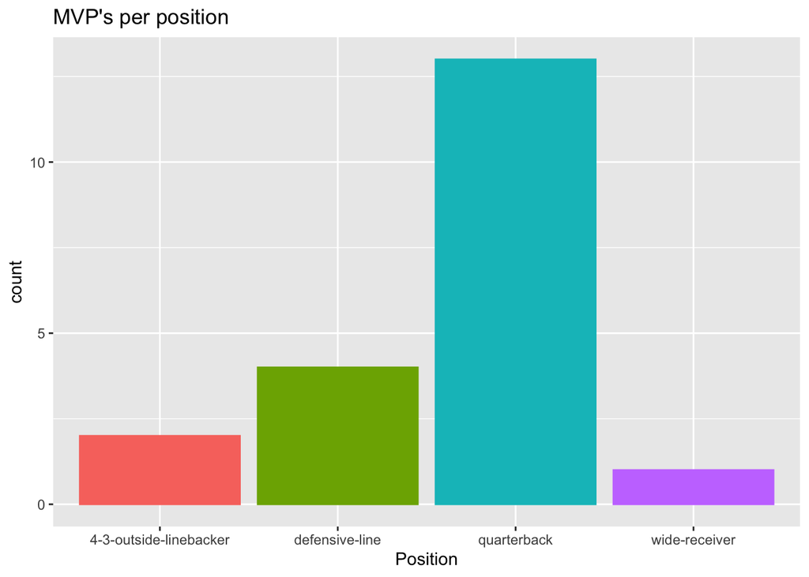

```r
ggplot(df_20, aes(x= position, color= position, fill= position)) +
    geom_bar(stat = "count") +
    labs(x = "Position") +
  theme(legend.position = "none")+
  ggtitle("MVP's per position")
```

# 6. What teams have the highest fully guaranteed expenses?

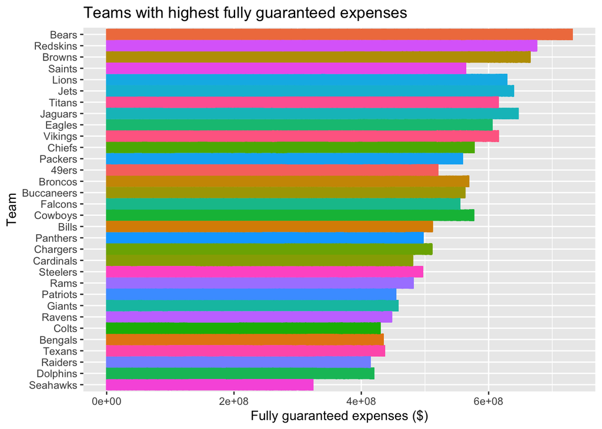

```r
# Grouping by teams
library(dplyr)
df_fully <- player_salary %>% group_by(team) %>% dplyr::summarize(fully_guaranteed_mean=(mean(fully_guaranteed)))

ggplot(player_salary, aes(x= reorder(team, +fully_guaranteed), y=fully_guaranteed, color= team, fill= team)) +
    geom_col() +
    labs(x = "Team", y= "Fully guaranteed expenses ($)") +
  theme(legend.position = "none") +
  ggtitle("Teams with highest fully guaranteed expenses") +
    coord_flip()
```

# 7. What is the relationship between coach salaries and their records?

```r
coach_record <- rename(coach_record, name = Name)
df_coach <- coach_record %>% merge(coach_salary, by = "name", all.x = TRUE)  %>%
  na.omit()
```

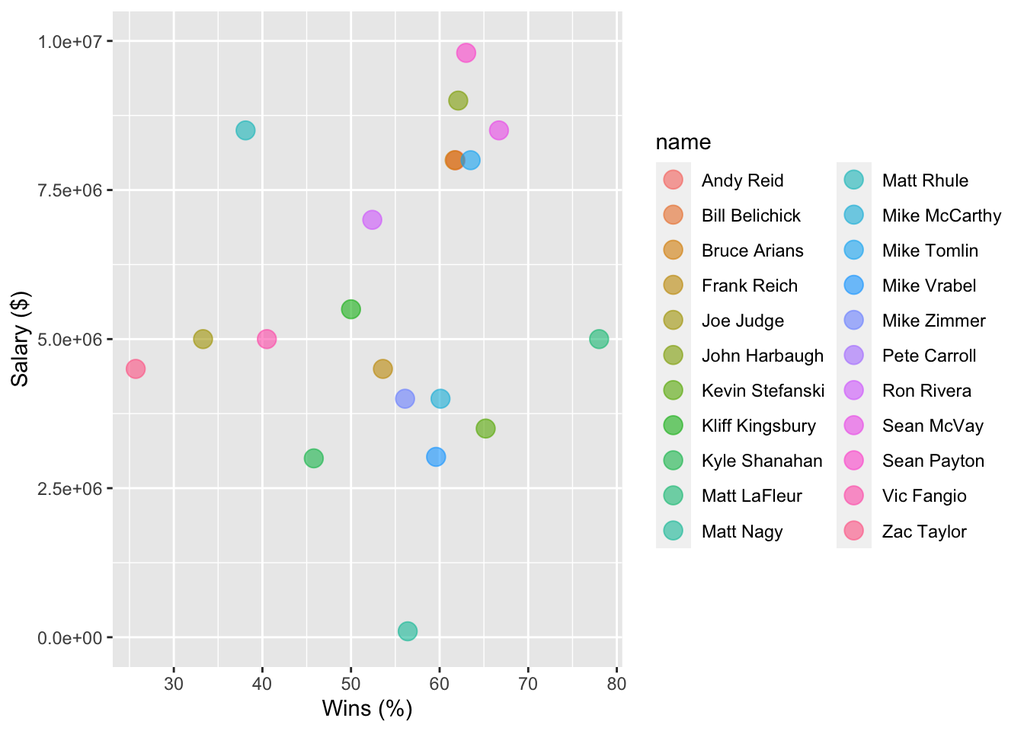

```r
ggplot(df_coach, aes(x= Pct*100, y=Annual_salary, color=name)) +
    geom_point(size=4, alpha=0.6) +
    labs(x = "Wins (%)", y= "Salary ($)") +
  #theme(legend.position = "none") +
  coord_trans(x= "identity", y= "identity", xlim= NULL,  ylim= c(0, 10e+6 ))
```